# STAT448 - Assignment 2

Dipin Ponthempilly Joseph (72746678), Nandakumar Thachapilly (35044765)

### Q1 a)

Set a seed at the beginning of your code equal to the last 4 numbers of your student id (or one of your student id’s if you work in pairs)

```r
# Setting seed for reproducibility
set.seed(4765)
```

### Q1 b)

Split the data set into a training set and a test set

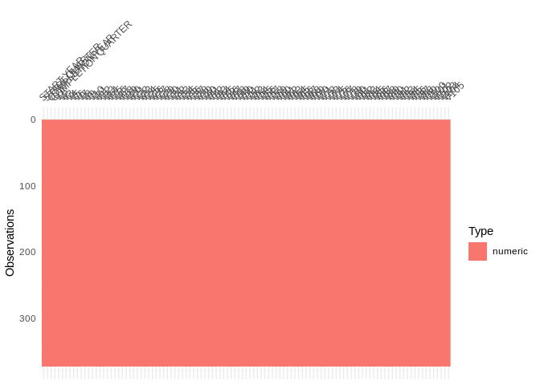

```r
# Working Directory
setwd("~/MEGA/SEM1-Feb-2020/BigData/A2/STAT448-Assignment_2/STAT448 - Assignment 2")

# Clear Environment
rm(list=ls())

# Load Environment from the given .RData file
load("Residen.RData")

# NA visualization - No NAs found
visdat::vis_dat(Residen)
```

```r
# Train/Test split in random at 0.8 ratio
row.number <- sample(1:nrow(Residen), 0.8*nrow(Residen))
train = Residen[row.number,]
test = Residen[-row.number,]

# Dimensions for Train/Test Data
dim(train)
```

```
## [1] 297 109
```

```r
dim(test)
```

```
## [1]  75 109
```

### Q1 c)

Fit a linear regression model on the training set to explain the ”actual sales price” (V104) in terms of the of the other variables excluding the variable ”actual construction costs” (V105). Report the test RMSE obtained.

```r
# Create Linear Regression Model with training data excluding variable V105
lm_model <- lm(V104 ~. -V105, data=train, trace=FALSE)
summary(lm_model)
```

```
##
## Call:
## lm(formula = V104 ~ . - V105, data = train, trace = FALSE)
##
## Residuals:
##     Min      1Q  Median      3Q     Max
## -771.57  -44.11   -1.96   43.07  609.42
##
## Coefficients: (34 not defined because of singularities)
##                        Estimate Std. Error t value Pr(>|t|)
## (Intercept)           2.650e+04  9.427e+04   0.281 0.778849
## `START YEAR`         -6.724e+02  1.490e+03  -0.451 0.652265
## `START QUARTER`       2.396e+03  3.809e+03   0.629 0.529977
## `COMPLETION YEAR`     1.841e+02  1.853e+01   9.937  < 2e-16 ***
## `COMPLETION QUARTER`  6.177e+01  9.978e+00   6.191 2.84e-09 ***
## V1                   -2.958e+00  2.601e+00  -1.137 0.256656
## V2                    9.140e-02  2.698e-02   3.387 0.000835 ***
## V3                   -2.871e-01  7.693e-02  -3.732 0.000241 ***
## V4                   -5.338e-02  4.008e-02  -1.332 0.184258
## V5                    3.127e-01  3.786e-01   0.826 0.409643
## V6                   -1.672e-02  6.615e-02  -0.253 0.800650
## V7                           NA         NA      NA       NA
## V8                    1.186e+00  1.897e-02  62.491  < 2e-16 ***
## V9                   -4.007e-01  3.321e-01  -1.207 0.228895
## V10                   5.817e+02  8.406e+02   0.692 0.489701
## V11                   1.414e+02  2.891e+02   0.489 0.625218
## V12                  -1.056e+02  1.398e+02  -0.756 0.450589
## V13                  -2.322e-02  1.682e-02  -1.381 0.168711
## V14                  -3.036e-01  7.375e-01  -0.412 0.680976
## V15                  -1.634e+01  5.228e+01  -0.313 0.754893
## V16                   4.597e+00  8.029e+00   0.573 0.567494
## V17                   1.035e-01  8.125e-02   1.274 0.203890
## V18                  -3.833e+02  3.840e+02  -0.998 0.319214
## V19                   4.210e+00  3.701e+00   1.137 0.256569
## V20                  -1.195e+00  1.964e+00  -0.609 0.543254
## V21                   2.670e-01  2.933e-01   0.910 0.363693
## V22                  -1.537e+00  1.458e+00  -1.054 0.293188
## V23                   2.620e+02  2.174e+02   1.205 0.229391
## V24                  -8.067e+02  8.678e+02  -0.930 0.353591
## V25                  -3.900e-01  6.348e-01  -0.614 0.539567
```

[output cut: 69 more lines]

```
## V95                          NA         NA      NA       NA
## V96                          NA         NA      NA       NA
## V97                          NA         NA      NA       NA
## V98                          NA         NA      NA       NA
## V99                          NA         NA      NA       NA
## V100                         NA         NA      NA       NA
## V101                         NA         NA      NA       NA
## V102                         NA         NA      NA       NA
## V103                         NA         NA      NA       NA
## ---
## Signif. codes:  0 '***' 0.001 '**' 0.01 '*' 0.05 '.' 0.1 ' ' 1
##
## Residual standard error: 142.6 on 223 degrees of freedom
## Multiple R-squared:  0.9884, Adjusted R-squared:  0.9846
## F-statistic:   261 on 73 and 223 DF,  p-value: < 2.2e-16
```

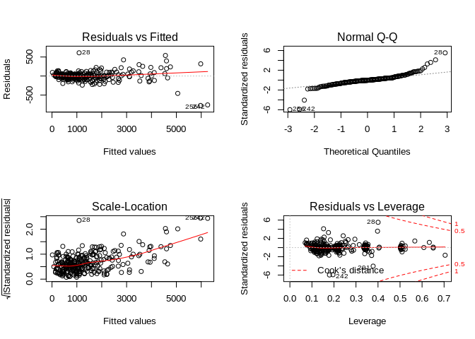

```r
par(mfrow=c(2,2))
plot(lm_model)
```

```r
# Predict the actual sales using linear regression model created.
lm_Predicted <- predict(lm_model, test)
# Calcuating the test RMSE of Linear regression model
lm_rmse <- sqrt(mean((test$V104 - lm_Predicted)^2))
c("Linear Regression Model RMSE" = lm_rmse)
```

```
## Linear Regression Model RMSE
##                      988.064
```

### Q1 d)

Fit a linear regression model using stepwise selection on the train- ing set. Report the test RMSE obtained.

```r
library(MASS)

# NULL Model
null_model = lm(V104 ~1, data=train)
#summary(null_model)

# Upper Model
upper_model = lm(V104 ~., data=train)
#summary(upper_model)

# Linear Regression with Stepwise Selection
lm_stepwise <- stepAIC(null_model, direction="both",trace=FALSE ,scope=list(upper=upper_model,lower=null_model))
summary(lm_stepwise)
```

```
##
## Call:
## lm(formula = V104 ~ V8 + V7 + V55 + V105 + V5 + V72 + V99 + V19 +
##     V84 + V65 + V86 + `COMPLETION QUARTER` + V1 + V23 + V35 +
##     V41 + V68, data = train)
##
## Residuals:
##     Min      1Q  Median      3Q     Max
## -822.99  -47.88   -0.47   41.95  644.01
##
## Coefficients:
##                        Estimate Std. Error t value Pr(>|t|)
## (Intercept)          -7.719e+01  4.945e+01  -1.561 0.119674
## V8                    1.185e+00  1.522e-02  77.838  < 2e-16 ***
## V7                    1.801e+01  5.687e+00   3.166 0.001717 **
## V55                   2.372e-03  9.168e-04   2.587 0.010191 *
## V105                  1.742e+00  2.859e-01   6.093 3.67e-09 ***
## V5                   -2.107e+00  4.284e-01  -4.919 1.49e-06 ***
## V72                  -1.307e+01  1.151e+00 -11.355  < 2e-16 ***
## V99                  -1.177e+01  4.735e+00  -2.485 0.013557 *
## V19                  -4.041e-01  9.710e-02  -4.161 4.22e-05 ***
## V84                   5.106e-04  1.371e-04   3.725 0.000236 ***
## V65                  -5.665e-04  1.811e-04  -3.128 0.001944 **
## V86                   9.761e+00  2.997e+00   3.257 0.001265 **
## `COMPLETION QUARTER`  1.249e+01  6.910e+00   1.807 0.071767 .
## V1                   -3.531e+00  1.983e+00  -1.781 0.076074 .
## V23                   2.815e+01  4.293e+00   6.558 2.64e-10 ***
## V35                  -1.822e-01  9.929e-02  -1.835 0.067594 .
## V41                  -3.688e-02  1.035e-02  -3.564 0.000430 ***
## V68                  -4.913e+00  2.847e+00  -1.726 0.085498 .
## ---
## Signif. codes:  0 '***' 0.001 '**' 0.01 '*' 0.05 '.' 0.1 ' ' 1
##
## Residual standard error: 129.6 on 279 degrees of freedom
## Multiple R-squared:  0.988,  Adjusted R-squared:  0.9873
## F-statistic:  1355 on 17 and 279 DF,  p-value: < 2.2e-16
```

```r
# Predication
lm_stepwise_pred <- predict(lm_stepwise, test)

# Calculating the test RMSE of Linear regression model
lm_step_rmse <- sqrt(mean((test$V104 - lm_stepwise_pred)^2))
c(Step_RMSE = lm_step_rmse)
```

```
## Step_RMSE
##  179.9235
```

### Q1 e)

Fit a linear regression model using ridge regression on the training set, with λ chosen by cross validation. Report the test RMSE obtained.

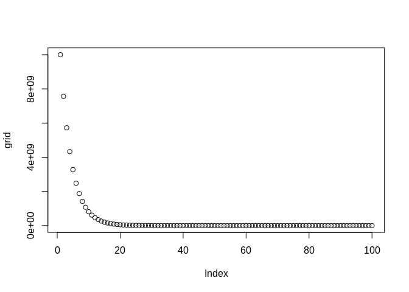

```r
# Ridge Regression
library(dplyr)
library(glmnet)
# create matricies for the regression equation
x = model.matrix(V104~. -V105,Residen)[,-1]
y = Residen %>%
  dplyr::select(V104) %>%
  unlist() %>%
  as.numeric()

x_train = model.matrix(V104~. -V105,train)[,-1]
y_train = train %>%
  dplyr::select(V104) %>%
  unlist() %>%
  as.numeric()

x_test = model.matrix(V104~. -V105,test)[,-1]
y_test = test %>%
  dplyr::select(V104) %>%
  unlist() %>%
  as.numeric()

grid=10^seq(10,-2,length=100)
plot(grid)
```

```r
ridge_mod = glmnet(x_train, y_train, alpha = 0, lambda = grid, thresh = 1e-12,trace=FALSE)
dim(coef(ridge_mod))
```

```
## [1] 108  77
```

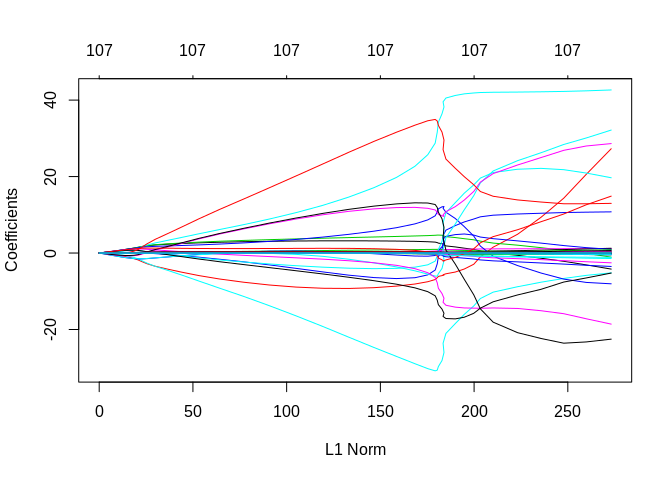

```r
plot(ridge_mod)
```

```r
cv.out = cv.glmnet(x_train, y_train, alpha = 0,trace=FALSE) # Fit ridge regression model on training data
bestlam = cv.out$lambda.min  # Select lamda that minimizes training MSE
c("Best Lambda for Ridge Regression" = bestlam)
```

```
## Best Lambda for Ridge Regression
##                         111.7434
```

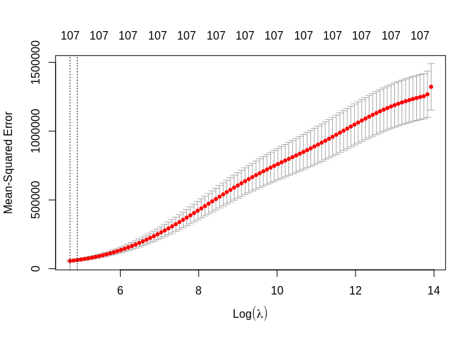

```r
plot(cv.out) # Draw plot of training MSE as a function of lambda
```

```r
log(bestlam)
```

```
## [1] 4.716205
```

```r
ridge_pred <- predict(ridge_mod, s = bestlam, newx = x_test) # Use best lambda to predict test data
rr_rmse <- sqrt(mean((y_test - ridge_pred)^2))
c(ridge_RMSE = rr_rmse)
```

```
## ridge_RMSE
##   275.9933
```

### Q1 f)

Fit a linear regression model using lasso on the training set, with λ chosen by cross validation. Report the test RMSE obtained along with the number of non-zero coefficient estimates.

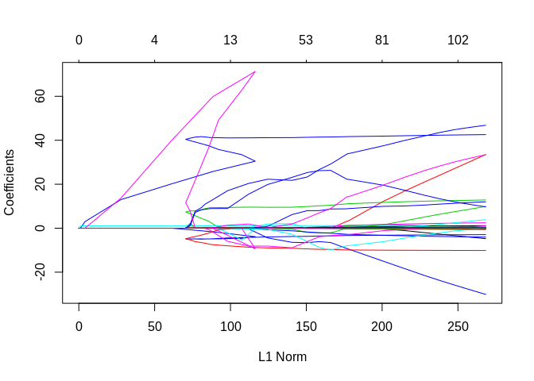

```r
# Lasso

lasso_mod=glmnet(x_train,y_train,alpha=1,lambda=grid,trace=FALSE) #fit lasso model on training data
plot(lasso_mod)                                       #Draw plot of coefficients
```

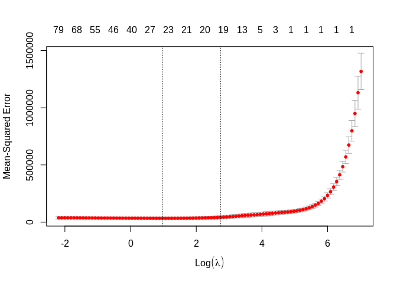

```r
cv.out=cv.glmnet(x_train,y_train,alpha=1,trace=FALSE)           #Fit lasso model on training data
plot(cv.out)
```

```r
bestlam=cv.out$lambda.min     #Select lambda that minimises training data
c("Best Lambda for lasso" = bestlam)
```

```
## Best Lambda for lasso
##               2.64216
```

```r
lasso_pred=predict(lasso_mod,s=bestlam,newx=x_test) #Use best lambda to predict test data
lo_rmse <- sqrt(mean((y_test - lasso_pred)^2))
c(lasso_RMSE = lo_rmse)
```

```
## lasso_RMSE
##    170.499
```

```r
out=glmnet(x,y,alpha=1,lambda=grid,trace=FALSE) #Fit lasso model on the full dataset
lasso_coeff=predict(out,type="coefficients",s=bestlam)[1:108,] #Display coefficients using lambda chosen by CV
# lasso_coeff
lasso_coeff[lasso_coeff !=0] #Display only non-zero coefficients
```

```
##          (Intercept)      `START QUARTER` `COMPLETION QUARTER`
##        -3.740964e+02        -9.003399e-02         1.519723e+01
##                   V1                   V2                   V3
##        -4.888822e+00         1.807806e-02        -5.880665e-02
##                   V4                   V5                   V6
##         2.527186e-02        -1.058666e-01         5.577437e-05
##                   V7                   V8                   V9
##         3.603639e+01         1.174640e+00         7.407918e-03
##                  V16                  V17                  V21
##         9.596553e-02         3.315491e-03         3.354576e-03
##                  V27                  V31                  V35
##         2.651942e-06         1.127268e+00         1.375261e-01
##                  V36                  V37                  V44
##         1.757573e-03         4.965824e-01         2.241692e-02
##                  V47                  V52                  V54
##         2.621094e-03        -4.431157e-03         1.912921e-02
##                  V55                  V66                  V69
##         4.909184e-03         4.885161e-03        -1.412788e-02
##                  V71                  V72                  V74
##        -7.024252e-03        -5.882857e+00         5.038468e-03
##                  V78                  V83                  V85
##         2.162572e-05        -2.047193e-05         5.780373e-03
##                  V92                  V94                  V97
##         1.047882e-03         1.515982e+01         4.927192e-03
```

### Q1 g)

Comment on the results obtained. How accurately can we predict the actual sale price? Is there much difference among the test errors resulting from these four approaches?

Test Root Mean Square Error by different models,

```r
rmse_t =matrix(c(lm_rmse,lm_step_rmse,rr_rmse,lo_rmse))
rownames(rmse_t) = (c("Linear Regression", "Linear Regression (Stepwise)",  "Ridge Regression", "LASSO"))
colnames(rmse_t) = c("Test RMSE")
as.table(rmse_t)
```

```
##                              Test RMSE
## Linear Regression             988.0640
## Linear Regression (Stepwise)  179.9235
## Ridge Regression              275.9933
## LASSO                         170.4990
```

From the test and train metrics model LASSO got the best performance with RMSE of 170.4990 on test data . Stepwise linear regression also performed well with RMSE of 179.9235.

```r
# Rsquared value of LASSO
rss <- sum((lasso_pred - y_test) ^ 2)  ## residual sum of squares
tss <- sum((y_test - mean(y_test)) ^ 2)  ## total sum of squares
rsq <- 1 - rss/tss
c("R-squared for test set in LASSO model" = rsq)
```

```
## R-squared for test set in LASSO model
##                             0.9852549
```

This means that 98.53 % variation in V104 can be explained from other predictor variables. The simple linear regression performed poorly while other three showed better performance. The main reason must be the multi colinearity present among predictor variables.